# Зачем студентам рассказывать про параметризацию эффектов

Если дамми-кодировка «обычно работает»

Курс по линейным моделям

## Проблема в одном слайде

Дамми-кодировка (treatment coding) даёт:

- правильные предсказания,
- правильные F-тесты,
- почти всегда.

**Но** студент, знающий только её, в определённый момент систематически начнёт **неправильно интерпретировать** результаты — и не заметит этого.

Effect coding преподаётся не как «альтернативный способ сделать то же самое», а как **лекарство от конкретных ошибок интерпретации**.

## Причина №1. Главные эффекты при взаимодействии

При treatment coding в модели с взаимодействием:

> коэффициент главного эффекта A — это эффект A **только в референтной категории B**.

Студент прочитает его как «эффект A вообще» — и это грубая ошибка, которая проходит незамеченной: p-значение и знак выглядят правдоподобно.

## Пример ловушки

- Базовая категория B = «контроль»: эффект A значим.
- Меняем базу на B = «группа 2»: эффект A незначим или противоположен.

**Вывод о «факторе» верен только для одной группы.**

Effect coding даёт главный эффект как отклонение от общего среднего (усреднённый по уровням другого фактора) — ровно то, что обычно подразумевают под «главным эффектом» в ANOVA.

## Условный vs маргинальный эффект

| Кодировка | Что означает главный эффект A |
| --- | --- |
| Treatment (дамми) | Эффект A **при референтной категории B** (условный) |
| Effect (sum-to-zero) | Эффект A, **усреднённый по уровням B** (маргинальный) |

Показать обе кодировки рядом — самый быстрый способ сделать разницу между «условным» и «маргинальным» эффектом осязаемой.

## Причина №2. Смена референсной категории

Студент, привыкший только к дамми, не понимает, почему при смене базы «все коэффициенты поменялись, а выводы те же».

Это выглядит как нестабильность модели и порождает:

- недоверие к результатам;
- соблазн «подобрать базу, где эффект значим» (p-hacking через референта).

Понимание, что кодировка — это **выбор базиса**, а не свойство данных, снимает и то, и другое.

## Причина №3. Связь с классической ANOVA-таблицей

Студенты учат ANOVA через

$$\alpha_i,\ \beta_j,\ (\alpha\beta)_{ij}, \quad \sum\alpha_i = 0,\ \sum\beta_j = 0,\ \sum(\alpha\beta)_{ij}=0$$

Это и есть **effect coding**.

Без показа этой связи у студента в голове живут две несвязанные картины: «ANOVA с эффектами» и «регрессия с дамми». Он не может перевести коэффициенты регрессии в эффекты ANOVA и наоборот.

## Причина №4. Type III SS и несбалансированный дизайн

При неравных размерах ячеек тесты главных эффектов (Type III) формулируются как гипотезы «при усреднении по другому фактору» — это буквально гипотезы effect coding.

Без этого студент не поймёт:

- что именно тестирует Type III SS;
- почему порядок факторов не влияет на Type III, но влияет на Type I;
- почему цифры в отчётах разных пакетов расходятся.

Ортогональные контрасты и планируемые сравнения тоже естественно живут в системе effect coding.

## Причина №5. Смешанные модели и повторные измерения

В mixed models и repeated measures параметризация эффектов часто удобнее:

- для задания структуры ковариаций;
- для интерпретации фиксированных эффектов.

Студент, знающий только дамми, при переходе к этим моделям оказывается в тупике.

## Причина №6. Профессиональная гигиена

Разница между кодировками — это разница между вопросами:

- «Насколько группа отличается от **контроля**?»
- «Насколько группа отличается от **среднего**?»

Оба вопроса законны. Но студент должен **выбирать кодировку под вопрос**, а не получать по умолчанию то, что выдал пакет, и потом интерпретировать это как попало.

Это и есть навык, который отличает специалиста от пользователя кнопки.

## Почему «обычно работает» — плохой аргумент

«Обычно» — это до первого случая:

- с взаимодействием,
- с несбалансированным дизайном,
- с необходимостью интерпретировать главные эффекты.

А такие случаи в реальной работе — **не исключение, а правило**.

## Дамми-кодировка не «неправильна» — она неполна

Она покрывает случаи с естественной референтной группой (контроль, «до») и оставляет студента без инструмента ровно там, где интерпретация становится тонкой.

Преподавать только её — значит готовить к тем 80% случаев, где всё просто, и молча оставлять 20%, где совершаются самые дорогие ошибки интерпретации.

## Итог

**Главная мысль**

Effect coding нужна в учебной программе не потому, что дамми-кодировка ломается математически, а потому что она ломает **интерпретацию** — тихо и правдоподобно.

Показать обе кодировки и разницу между «условным» и «маргинальным» эффектом — это прививка от целого класса ошибок, которые иначе студент совершит через год на реальных данных и не узнает об этом.

## Мини-упражнение для студентов

1. Подгоните модель `y ~ A * B` с treatment coding.
2. Запишите коэффициент главного эффекта A.
3. Смените референтную категорию B. Запишите коэффициент снова.
4. Объясните, почему он изменился, хотя модель «та же».
5. Повторите с effect coding. Сравните интерпретацию.

**Вопрос на понимание:** в каком случае главный эффект A не имеет смысла ни при какой кодировке?

## Что мы хотим показать

При **treatment coding** в модели с взаимодействием коэффициент главного эффекта A — это эффект A **только в референтной категории B**.

Мы сгенерируем данные, в которых эффект A **меняет знак** по уровням B, и увидим, как «главный эффект A» прыгает при смене базы — хотя данные одни и те же.

## Дизайн симуляции

- Фактор **A**: 2 уровня (`a0`, `a1`) — интересующий нас фактор.
- Фактор **B**: 3 уровня (`b0`, `b1`, `b2`) — модератор.
- Сбалансированный дизайн: по 60 наблюдений в ячейке.
- Истинный эффект A **внутри** каждого уровня B:

| B | эффект A (истина) |
| --- | --- |
| b0 | **+2.0** (сильный, значимый) |
| b1 | **0.0** (нулевой) |
| b2 | **−2.0** (противоположный) |

Маргинальный эффект A (среднее по B) = **0**. Но это не значит, что A «не влияет»!

## Генерируем данные

## Истинные средние по ячейкам

Среднее y в каждой ячейке (без шума)

| A | B | mean_y |
| --- | --- | --- |
| a0 | b0 | 7 |
| a1 | b0 | 9 |
| a0 | b1 | 10 |
| a1 | b1 | 10 |
| a0 | b2 | 13 |
| a1 | b2 | 11 |

Видно, что линии A по уровням B идут **веером**: от `a0` к `a1` разница меняется с `+2` на `−2`. Это и есть взаимодействие.

## Вспомогательная функция

## Treatment coding: база B = b0

[output not shown]

## Treatment coding: база B = b1

[output not shown]

**Данные те же. Модель та же. Вывод противоположный.**

## Treatment coding: база B = b2

[output not shown]

## Все три базы рядом

Один и тот же фактор A — три разных «главных эффекта»

[output not shown]

## Effect coding: база не нужна

Effect coding: коэффициент A не зависит от базы B

[output not shown]

## Что на самом деле означает «эффект A»

Условный эффект A внутри каждого B

| contrast | B | estimate | SE | df | t.ratio | p.value |
| --- | --- | --- | --- | --- | --- | --- |
| a1 - a0 | b0 | 2.132374 | 0.183041 | 354 | 11.64971 | 0.0000000 |
| a1 - a0 | b1 | 0.039061 | 0.183041 | 354 | 0.21340 | 0.8311378 |
| a1 - a0 | b2 | -2.067330 | 0.183041 | 354 | -11.29435 | 0.0000000 |

Маргинальный эффект A (усреднён по B)

| contrast | estimate | SE | df | t.ratio | p.value |
| --- | --- | --- | --- | --- | --- |
| a1 - a0 | 0.0347018 | 0.1056788 | 354 | 0.3283701 | 0.742826 |

«Главный эффект» — это **не одно число**, пока есть взаимодействие. Нужно явно сказать: условный (при данном B) или маргинальный.

## Визуально: взаимодействие налицо

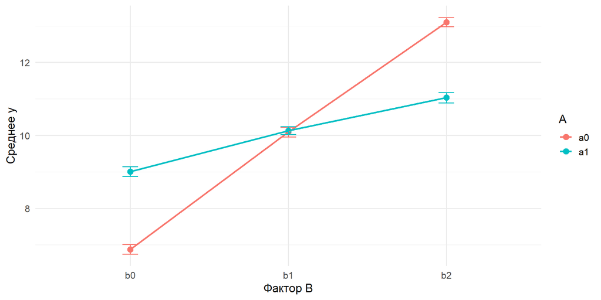

Среднее y по ячейкам: эффект A меняет знак по уровням B

## Омнибус-тест не зависит от базы

F-тест взаимодействия одинаков при любой базе

| база | F_взаимодействия |
| --- | --- |
| b0 | 131.608 |
| b1 | 131.608 |
| b2 | 131.608 |

**Тесты устойчивы к кодировке. Коэффициенты — нет.** Отсюда мораль: устойчивость тестов не спасает от ошибок интерпретации.

## Мораль

**Главное**

- **Treatment coding**: коэффициент A зависит от выбора базы B. При разных базах — значимый, нулевой, противоположный.
- **Effect coding**: один и тот же коэффициент A при любой базе — маргинальный эффект, усреднённый по B.
- При наличии взаимодействия «главный эффект» требует **явного определения**: условный (при данном B) или маргинальный.

Показать обе кодировки рядом — самый быстрый способ сделать разницу между «условным» и «маргинальным» эффектом осязаемой.

## Вопрос студентам

1. Какой из трёх коэффициентов treatment coding — «эффект A»?
2. Почему F-тест взаимодействия не меняется при смене базы, а коэффициент — меняется?
3. В каком случае «главный эффект A» не имеет смысла ни при какой кодировке?

**Подсказка к №3:** когда взаимодействие значимо и линии пересекаются — тогда единого «эффекта A» просто нет.